# SHC 798 Assignment 2, 2025

Richard Lubega

2025-10-06

# SHC 798 Assignment 2, 2025

## Analysis of Variance (ANOVA)

### Question 5: Compressive strength for concrete

```r
pacman::p_load(tidymodels)

# Getting started with the dataset in curing.csv :
curing <- read.csv(file.choose(), header = TRUE, na.strings = c("NA"))
curing
```

```
##    method strength
## 1   water     44.5
## 2   water     37.7
## 3   water     38.5
## 4   water     40.9
## 5   water     43.9
## 6   water     41.9
## 7   water     41.3
## 8   water     44.7
## 9   water     46.3
## 10  water     43.3
## 11  water     40.8
## 12  water     41.2
## 13  water     39.4
## 14  water     42.2
```

[output cut: 16 more lines]

```r
head(curing)
```

```
##   method strength
## 1  water     44.5
## 2  water     37.7
## 3  water     38.5
## 4  water     40.9
## 5  water     43.9
## 6  water     41.9
```

```r
str(curing)
```

```
## 'data.frame':    30 obs. of  2 variables:
##  $ method  : chr  "water" "water" "water" "water" ...
##  $ strength: num  44.5 37.7 38.5 40.9 43.9 41.9 41.3 44.7 46.3 43.3 ...
```

```r
## Convert species column to a factor
curing$method <- factor(curing$method)
## Check levels
levels(curing$method)
```

```
## [1] "air"   "water"
```

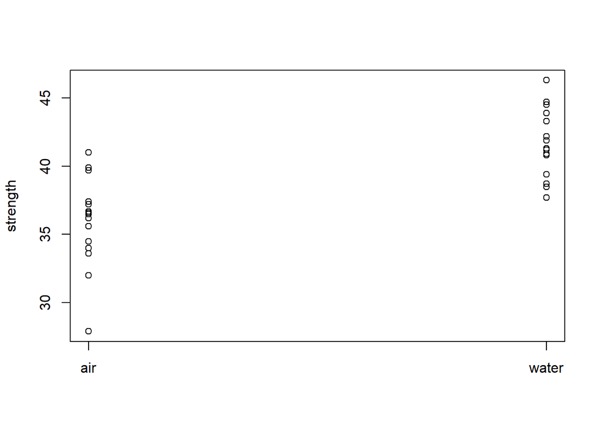

```r
## Visualize data
stripchart(strength ~ method, data = curing, pch = 1, vertical = TRUE)
```

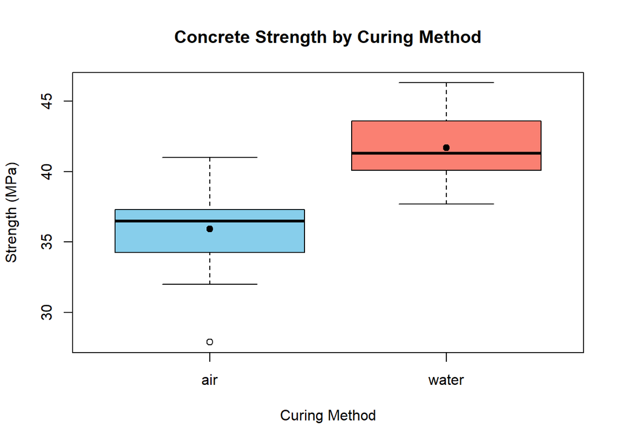

```r
# Part a): # Box Plots
# Box plots

# Side-by-side boxplots of strength by curing method
boxplot(strength ~ method, data = curing,
        main = "Concrete Strength by Curing Method",
        xlab = "Curing Method",
        ylab = "Strength (MPa)",
        col = c("skyblue", "salmon"))

#Adding means as points
means <- tapply(curing$strength, curing$method, mean)
points(1:2, means, pch = 19, col = "black")
```

```r
# Annotate outliers on the plot
# text(x = bp$group, y = bp$out, labels = bp$out, pos = 3, cex = 0.7, col = "blue")
```

#### **Inspecting Difference in Strength**

From the box plots, the box for water is higher than the box for air. The Whiskers indicate that he upper range of air overlaps slightly with the lower range of water, but most water values are consistently higher.

Based on this, it appears likely that the two curing methods would produce significantly different strengths where water curing produces higher strengths than air curing.

```r
# Part b): # A two-sample t-test
tapply(curing$strengt, curing$method, sd) # check for group SD
```

```
##      air    water
## 3.296362 2.508234
```

```r
tapply(curing$strengt, curing$method, var) # check for group var
```

```
##       air     water
## 10.866000  6.291238
```

```r
# t.test(strength ~ method, data = curing, var.equal = TRUE)
t.test(strength ~ method, data = curing, var.equal = FALSE)
```

```
##
##  Welch Two Sample t-test
##
## data:  strength by method
## t = -5.392, df = 26.141, p-value = 1.178e-05
## alternative hypothesis: true difference in means between group air and group water is not equal to 0
## 95 percent confidence interval:
##  -7.964463 -3.568871
## sample estimates:
##   mean in group air mean in group water
##            35.92000            41.68667
```

### **Model Interpretation**

**Test method**: The Welch’s t-test (does not assume equal variances).

*Null hypothesis* (H<sub>O</sub>): 𝜇<sub>water</sub> = 𝜇<sub>air</sub> (mean compressive strength is the same for both curing methods).

*Alternative hypothesis* (H<sub>A</sub>): 𝜇<sub>water</sub> != 𝜇<sub>air</sub> (mean compressive strength differs between the two curing methods).

```r
# Part c) test statistic, p-value, and conclusion
```

### **Test Results**

**t-statistic**: -5.392

**p-value**: 1.178e-05

**Conclusion**: The p-value is much smaller than 0.05, so we reject the null hypothesis. There is **strong evidence** that the mean strengths **differ** between the two curing methods. Water curing results in significantly higher mean strength than air curing.

```r
# Part d) # practical significance

Mean.diff <- 41.68667- 35.92000
print("Difference in means is:")
```

```
## [1] "Difference in means is:"
```

```r
print(Mean.diff)
```

```
## [1] 5.76667
```

Therefore, the difference is both statistically significant (very low p-value) and practically significant because it represents a meaningful improvement in strength due to water curing